# pyMódulo 05

Curso IE0217 Estructuras abstractas y algoritmos para ingeniería - UCR

Profesor Freddy Rojas Ch.

14/06/2022

# Lenguaje Python 3 Módulo 5

## Graficación

En el módulo 5 de Python se explora la graficación de información mediante la librería *matplotlib*.

Para ello se debe instalar (según se indicó la forma de instalar paquetes en el módulo 3) el paquete *matplotlib* para poder acceder a estas funcionalidades.

El primer ejemplo consiste en hacer la graficación de ondas senosoidales.

```python
import matplotlib.pyplot as plt
import numpy as np

#import seaborn

plt.style.use('classic') # Estilo clÃ¡sico

# Ejemplos de grÃ¡ficos de lÃneas (graficando funciones)
# Datos del eje X para los siguientes grÃ¡ficos
x = np.linspace(0, 10, 100)
x

# Lo siguiente se ejecuta todo junto
```

```
## array([ 0.        ,  0.1010101 ,  0.2020202 ,  0.3030303 ,  0.4040404 ,
##         0.50505051,  0.60606061,  0.70707071,  0.80808081,  0.90909091,
##         1.01010101,  1.11111111,  1.21212121,  1.31313131,  1.41414141,
##         1.51515152,  1.61616162,  1.71717172,  1.81818182,  1.91919192,
##         2.02020202,  2.12121212,  2.22222222,  2.32323232,  2.42424242,
##         2.52525253,  2.62626263,  2.72727273,  2.82828283,  2.92929293,
##         3.03030303,  3.13131313,  3.23232323,  3.33333333,  3.43434343,
##         3.53535354,  3.63636364,  3.73737374,  3.83838384,  3.93939394,
##         4.04040404,  4.14141414,  4.24242424,  4.34343434,  4.44444444,
##         4.54545455,  4.64646465,  4.74747475,  4.84848485,  4.94949495,
##         5.05050505,  5.15151515,  5.25252525,  5.35353535,  5.45454545,
##         5.55555556,  5.65656566,  5.75757576,  5.85858586,  5.95959596,
##         6.06060606,  6.16161616,  6.26262626,  6.36363636,  6.46464646,
##         6.56565657,  6.66666667,  6.76767677,  6.86868687,  6.96969697,
##         7.07070707,  7.17171717,  7.27272727,  7.37373737,  7.47474747,
##         7.57575758,  7.67676768,  7.77777778,  7.87878788,  7.97979798,
##         8.08080808,  8.18181818,  8.28282828,  8.38383838,  8.48484848,
##         8.58585859,  8.68686869,  8.78787879,  8.88888889,  8.98989899,
##         9.09090909,  9.19191919,  9.29292929,  9.39393939,  9.49494949,
##         9.5959596 ,  9.6969697 ,  9.7979798 ,  9.8989899 , 10.        ])
```

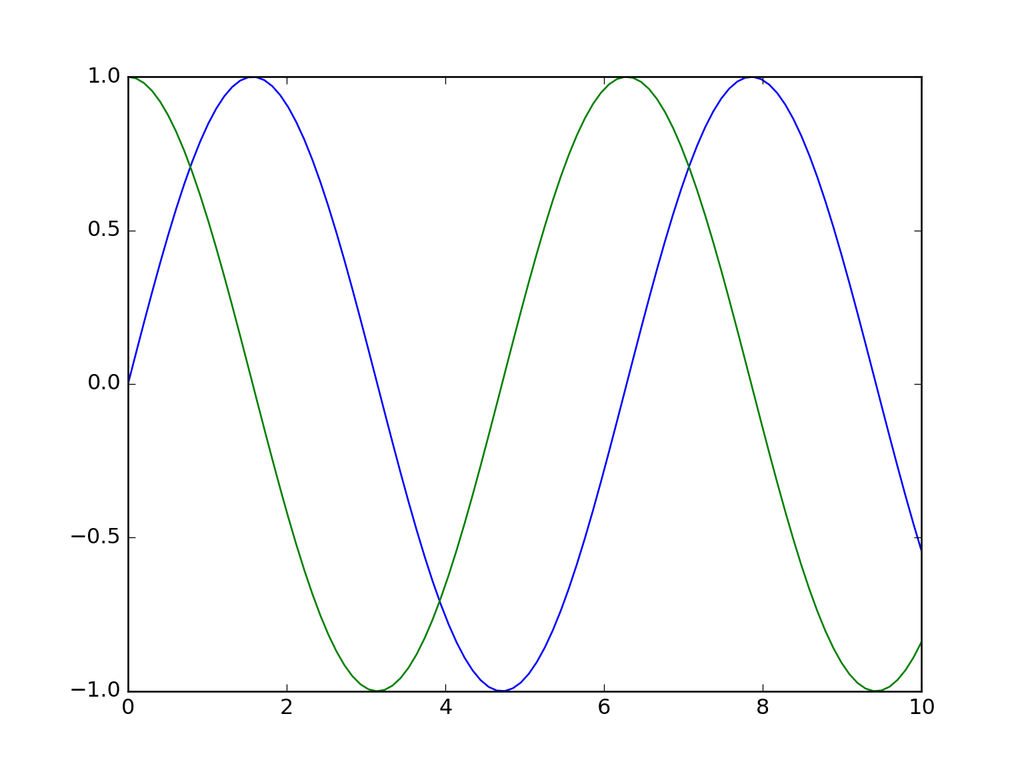

```python
plt.plot(x, np.sin(x))
plt.plot(x, np.cos(x))
plt.show()
```

```python
plt.close()
```

Impresión con trazos.

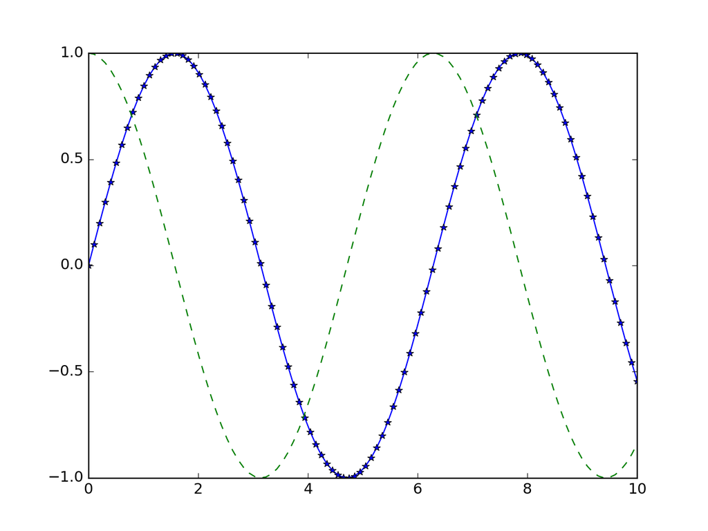

```python
plt.plot(x, np.sin(x), '-*')
plt.plot(x, np.cos(x), '--');
plt.show()
```

```python
plt.close()
```

Doble gráfico usando “sub plots”

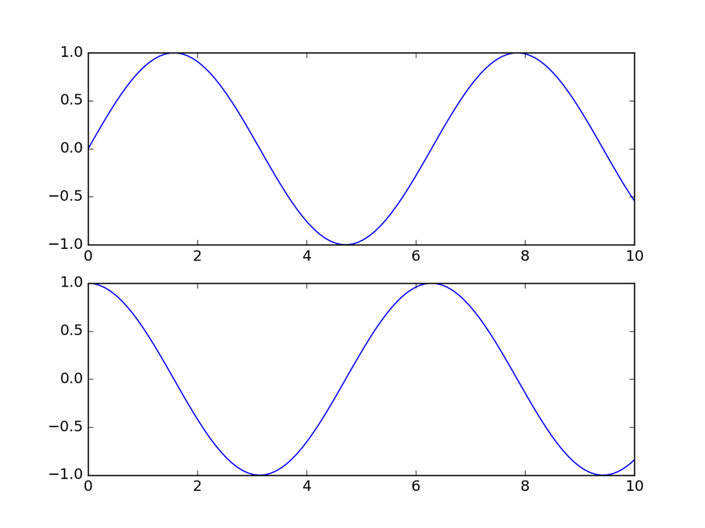

```python
# Crea el primer panel
plt.subplot(2, 1, 1) # (filas, columnas, nÃºmero de paneles)
plt.plot(x, np.sin(x))
# crea el segundo panel
plt.subplot(2, 1, 2)
plt.plot(x, np.cos(x))
plt.show()
```

```python
plt.close()
```

Otra forma doble

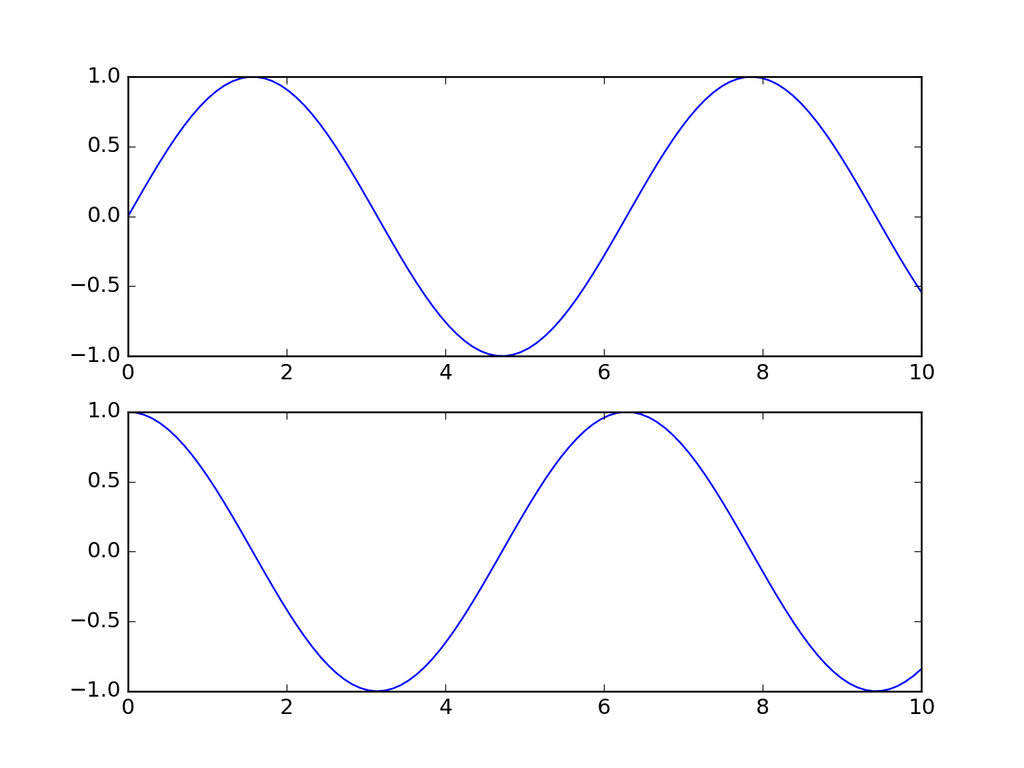

```python
# Un estilo Orientado a Objetos para situaciones mÃ¡s complejas
# Crea la figura y ax un arreglo de dos objectos
fig, ax = plt.subplots(2)
# Llama el mÃ©todo plot() method
ax[0].plot(x, np.sin(x))
ax[1].plot(x, np.cos(x))
plt.show()
```

```python
plt.close()
```

Definiendo un objeto asociado ‘fig’

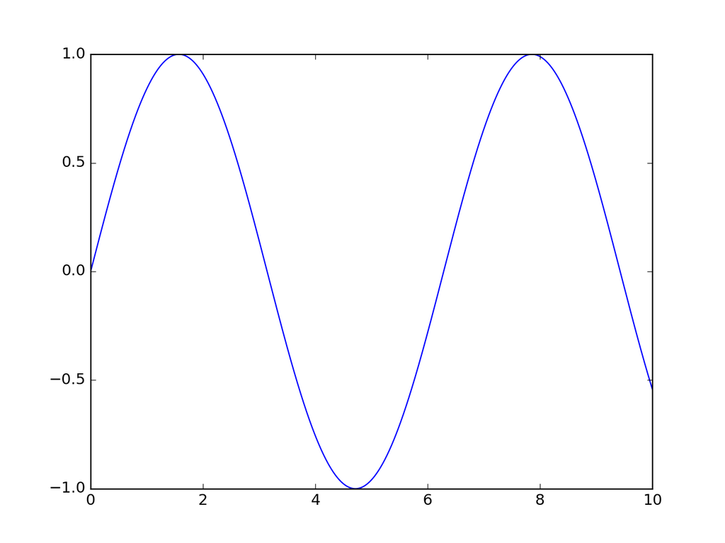

```python
# Otro ejemplo Orientado a Objetos
fig = plt.figure()
ax = plt.axes()
x = np.linspace(0, 10, 1000)
ax.plot(x, np.sin(x))
plt.show()
```

```python
plt.close()
```

Estilo funcional

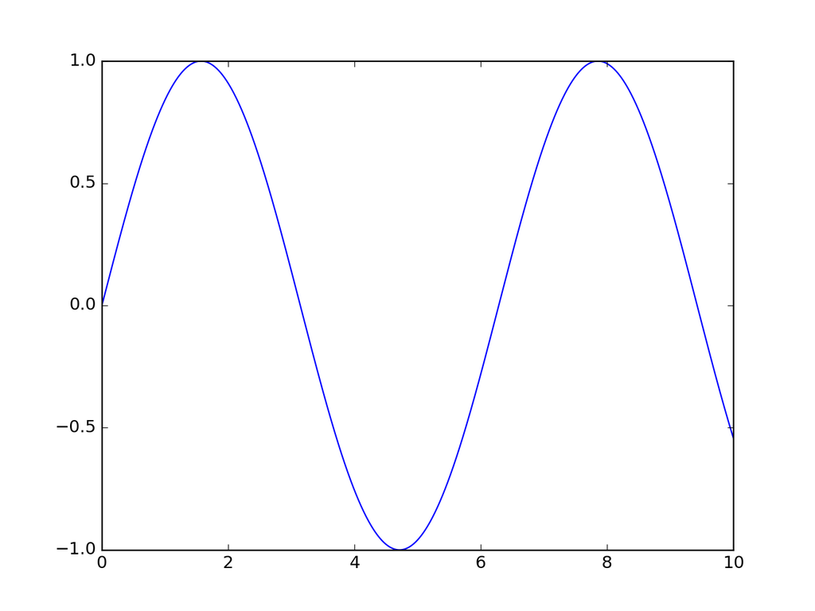

```python
# Estilo funcional
x = np.linspace(0, 10, 1000)
plt.plot(x, np.sin(x))
plt.show()
```

```python
plt.close()
```

Usando colores en diferentes gráficos

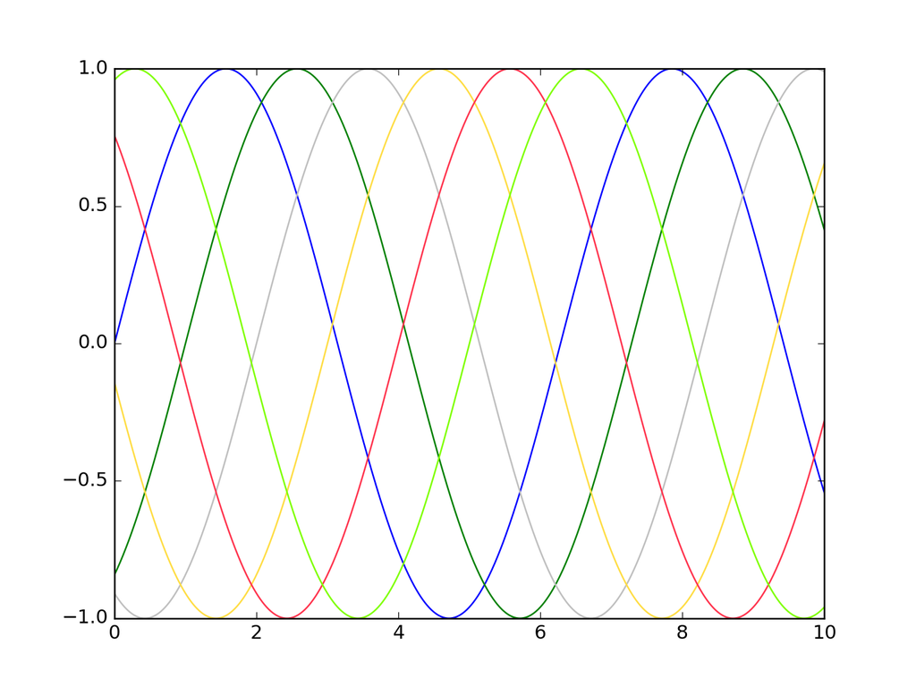

```python
# Usando colores
plt.plot(x, np.sin(x - 0), color='blue')        # Nombre del color
plt.plot(x, np.sin(x - 1), color='g')           # CÃ³digo del color (rgbcmyk)
plt.plot(x, np.sin(x - 2), color='0.75')        # escala de gris entre 0 y 1
plt.plot(x, np.sin(x - 3), color='#FFDD44')     # CÃ³digo exadecimal (RRGGBB from 00 to FF)
plt.plot(x, np.sin(x - 4), color=(1.0,0.2,0.3)) # Tupla RGB entre 0 y 1
plt.plot(x, np.sin(x - 5), color='chartreuse') # Nombres de color en HTML
plt.show()
```

```python
plt.close()
```

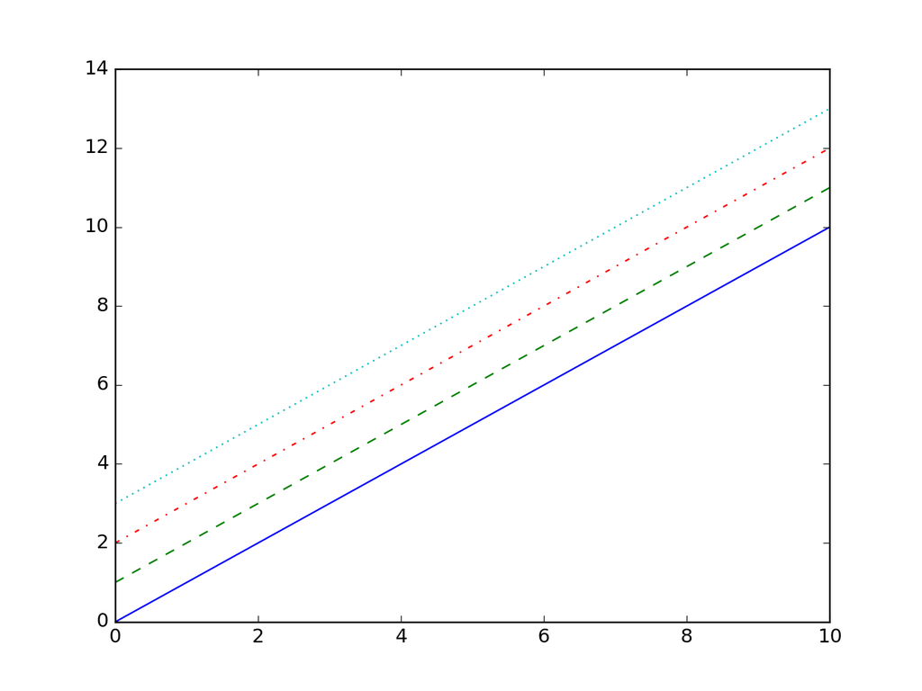

```python
plt.plot(x, x + 0, linestyle='solid')
plt.plot(x, x + 1, linestyle='dashed')
plt.plot(x, x + 2, linestyle='dashdot')
plt.plot(x, x + 3, linestyle='dotted')
plt.show()
```

```python
plt.close()
```

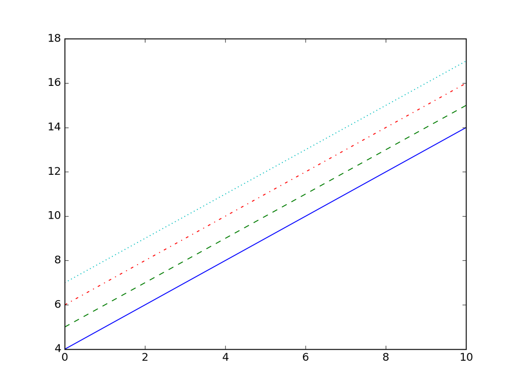

```python
# Lo mismo pero con cÃ³digo
plt.plot(x, x + 4, linestyle='-')
plt.plot(x, x + 5, linestyle='--')
plt.plot(x, x + 6, linestyle='-.')
plt.plot(x, x + 7, linestyle=':')
plt.show()
```

```python
plt.close()
```

Ajustando el eje X

```python
# Cambiando los lÃmites de los ejes
# Evaluar todo junto
plt.plot(x, np.sin(x))
plt.xlim(-1, 11)
```

```
## (-1.0, 11.0)
```

```python
plt.ylim(-1.5, 1.5)
```

```
## (-1.5, 1.5)
```

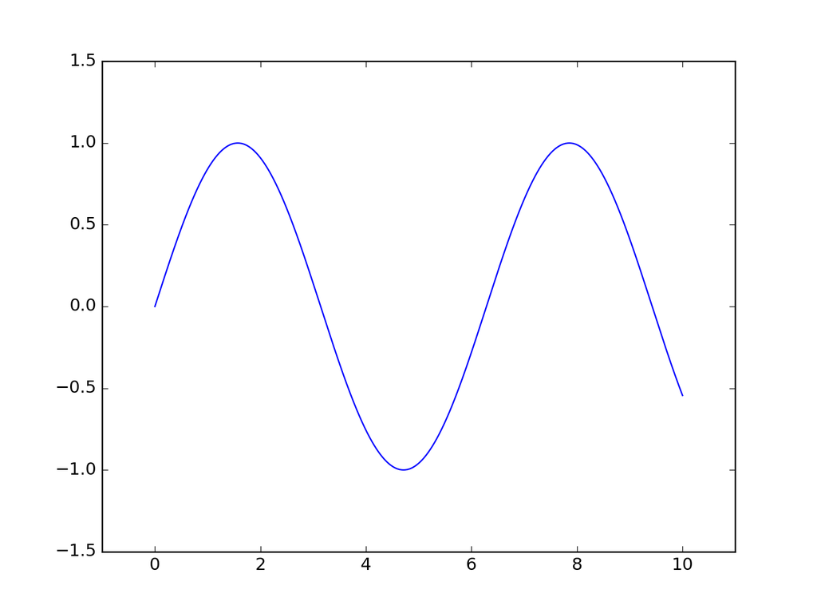

```python
plt.show()
```

```python
plt.close()
```

```python
# Otro ejemplo
plt.plot(x, np.sin(x))
plt.axis('tight')
```

```
## (0.0, 10.0, -0.9999972954811321, 0.9999996994977832)
```

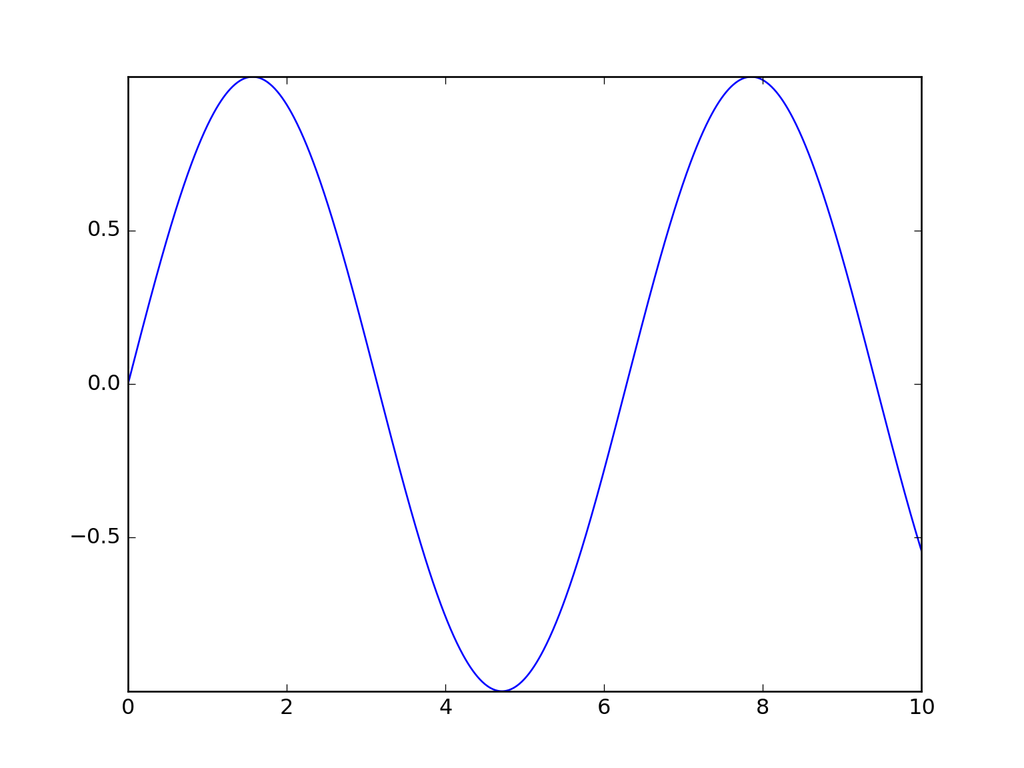

```python
plt.show()
```

### Titulos y etiquetas en los ejes.

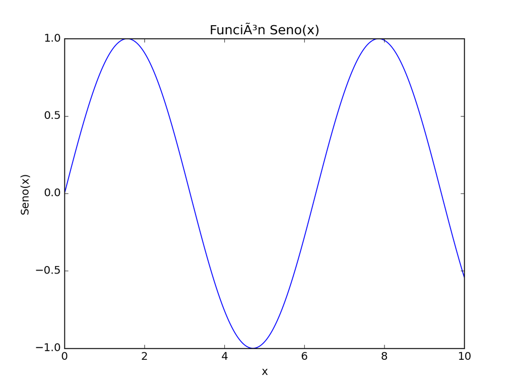

```python
# TÃtulos
plt.plot(x, np.sin(x))
plt.title("FunciÃ³n Seno(x)")
plt.xlabel("x")
plt.ylabel("Seno(x)")
plt.show()
```

Leyendas en el gráfico

```python
# Leyendas
plt.plot(x, np.sin(x), '-g', label='Seno(x)')
plt.plot(x, np.cos(x), ':b', label='Coseno(x)')
plt.axis('equal')
```

```
## (0.0, 10.0, -1.0, 1.0)
```

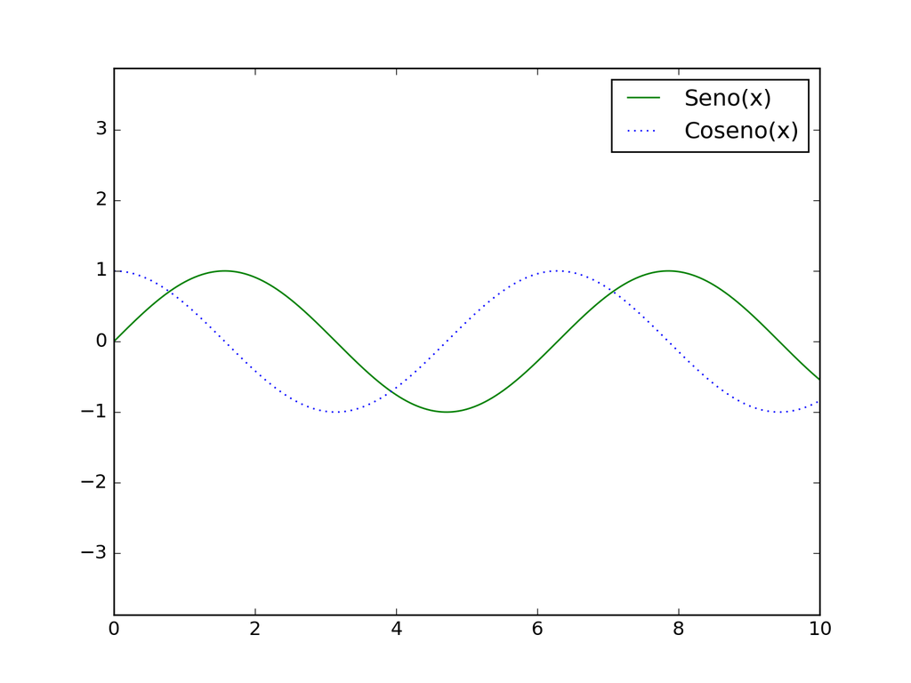

```python
plt.legend()
plt.show()
```

Orientado a objetos

```python
# Orientado a Objetos
ax = plt.axes()
ax.plot(x, np.sin(x))
ax.set(xlim=(0, 10), ylim=(-2, 2),
       xlabel='x', ylabel='Seno(x)',
       title='Un ploteo de Seno(x)')
```

```
## [(0.0, 10.0), (-2.0, 2.0), Text(0.5, 0, 'x'), Text(0, 0.5, 'Seno(x)'), Text(0.5, 1.0, 'Un ploteo de Seno(x)')]
```

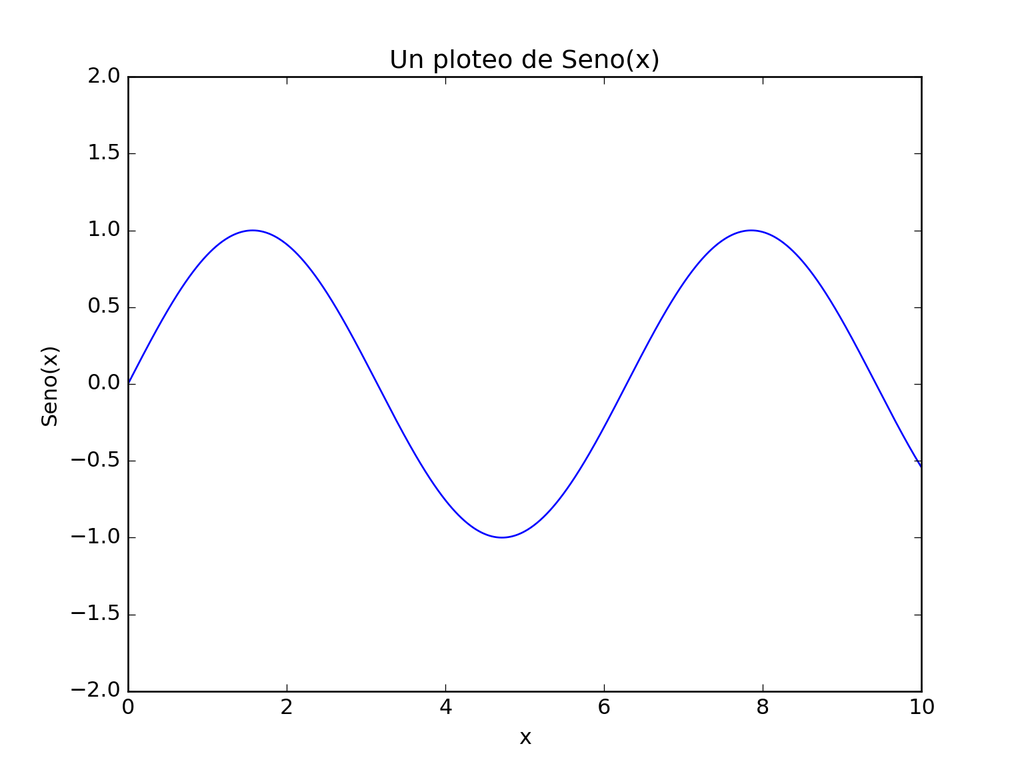

```python
plt.show()
```

A la izquierda como función de matplotlib

A la derecha como método del objeto ax

plt.xlabel() → ax.set_xlabel()

plt.ylabel() → ax.set_ylabel()

plt.xlim() → ax.set_xlim()

plt.ylim() → ax.set_ylim()

plt.title() → ax.set_title()

Gráficos tipo “scatter Ejemplo 1

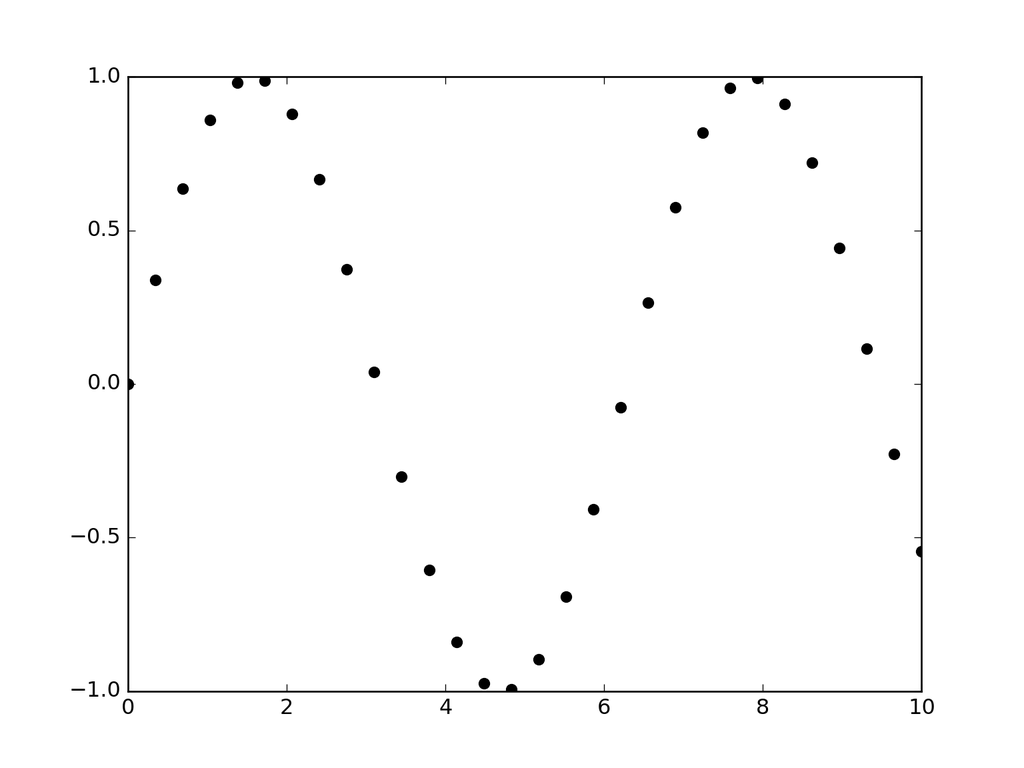

```python
# GrÃ¡ficos scatter plot = Ejes XY
# Comando plot

# Ejemplo 1
x = np.linspace(0, 10, 30)
y = np.sin(x)
plt.plot(x, y, 'o', color='black')
plt.show()
```

Ejemplo 2

```python
# Ejemplo 2
rng = np.random.RandomState(0)
for marca in ['o', '.', ',', 'x', '+', 'v', '^', '<', '>', 's', 'd']:
    plt.plot(rng.rand(5), rng.rand(5), marca,
             label="marca='{0}'".format(marca))
plt.legend(numpoints=1)
plt.xlim(0, 1.8)
```

```
## (0.0, 1.8)
```

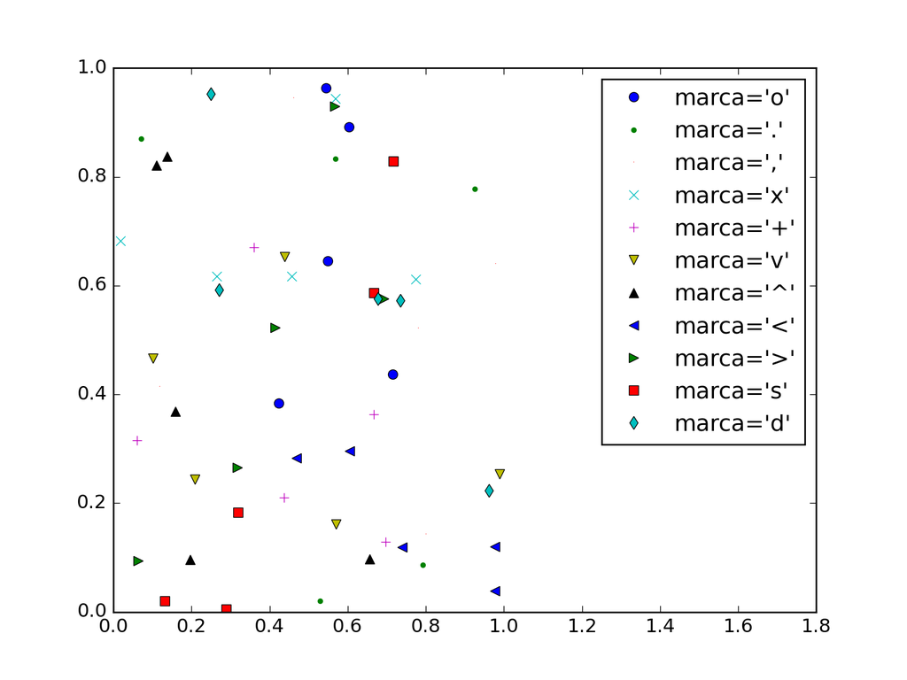

```python
plt.show()
```

Ejemplo 3

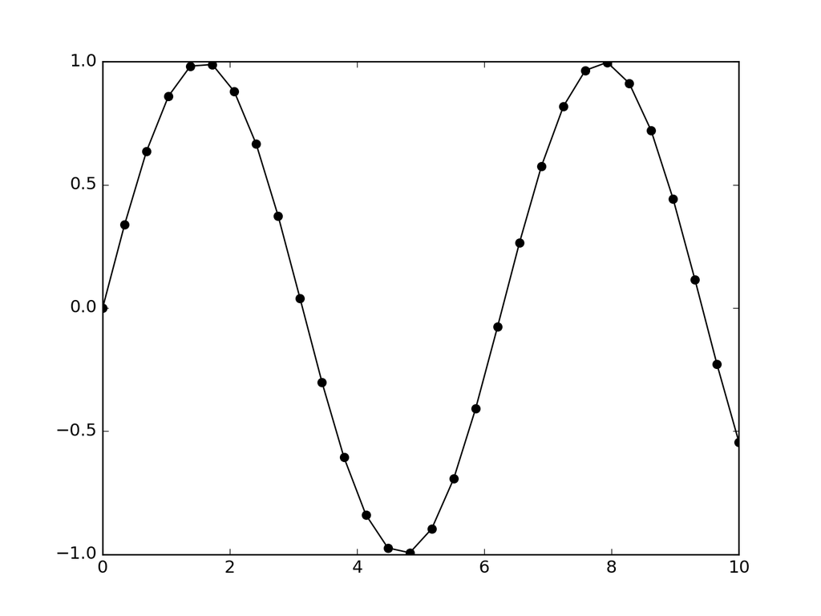

```python
# Ejemplo 3
plt.plot(x, y, '-ok')
plt.show()
```

Ejemplo 4

```python
# Ejemplo 4
plt.plot(x, y, '-p', color='gray',
         markersize=15, linewidth=4,
         markerfacecolor='white',
         markeredgecolor='gray',
         markeredgewidth=2)
plt.ylim(-1.2, 1.2)
```

```
## (-1.2, 1.2)
```

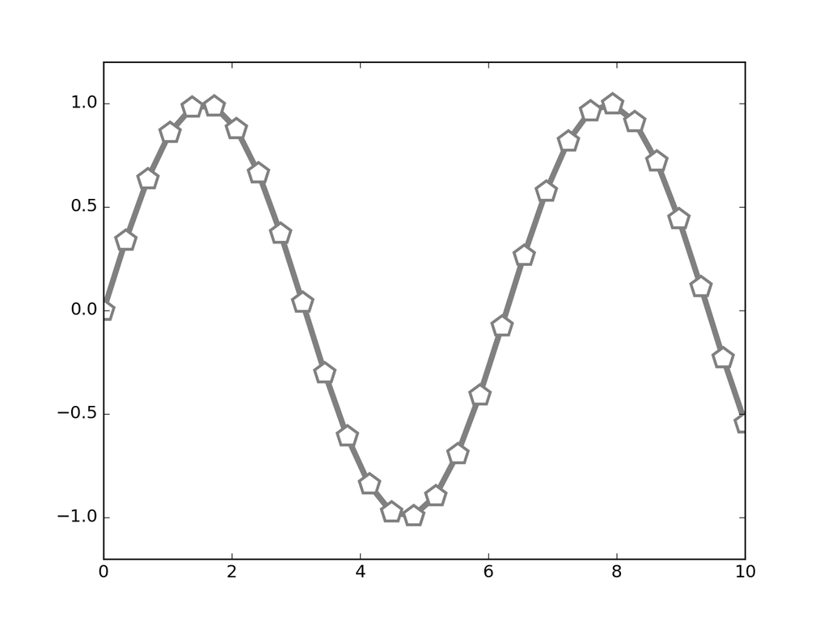

```python
plt.show()
```

```python
plt.close()
```

Ejemplo 5

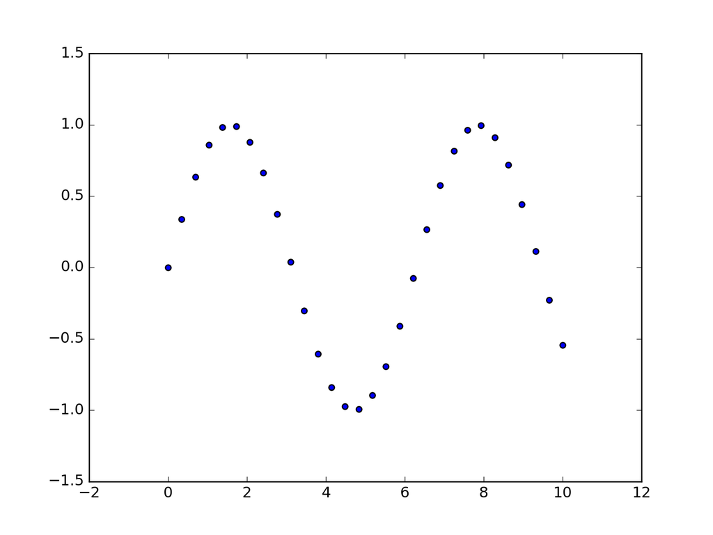

```python
# Comando scatter, mÃ¡s potente

# Ejemplo 5
plt.scatter(x, y, marker='o')
plt.show()
```

```python
plt.close()
```

Ejemplo 6

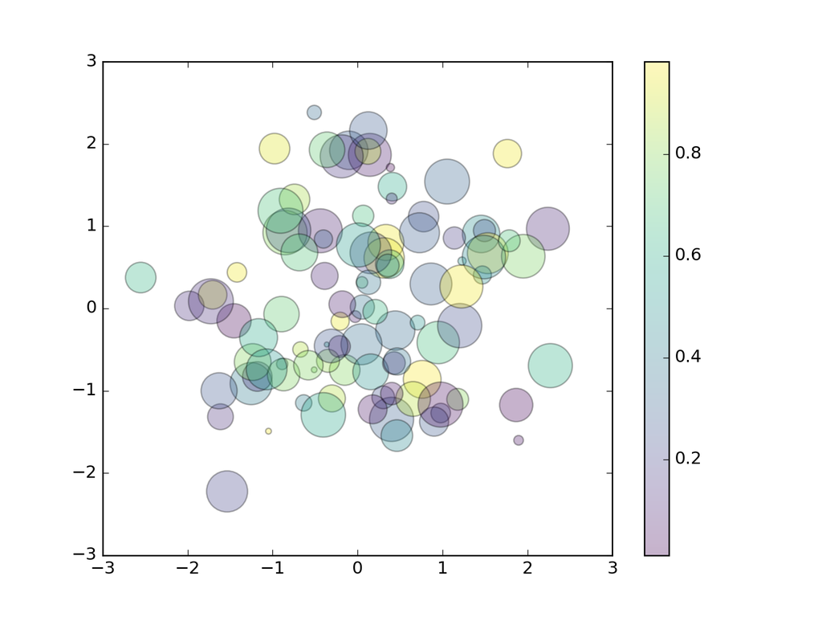

```python
# Ejemplo 6

rng = np.random.RandomState(0)
x = rng.randn(100)
y = rng.randn(100)
colores = rng.rand(100)
tamanos = 1000 * rng.rand(100)
x=plt.scatter(x, y, c=colores, s=tamanos, alpha=0.3,cmap='viridis')
x=plt.colorbar()
plt.show()
```

```python
plt.close()
```

## Uso de data frames en gráficos

```python
### INSTALAR pip3 sklearn

import pandas as pd
from sklearn.datasets import load_iris
iris = load_iris()
print("Nombres de variables:",iris.target_names)
```

```
## Nombres de variables: ['setosa' 'versicolor' 'virginica']
```

```python
print("Nombres de mediciones para cada variable:",iris.feature_names)

# Convertir IRIS a Data Frame para observar componentes.
```

```
## Nombres de mediciones para cada variable: ['sepal length (cm)', 'sepal width (cm)', 'petal length (cm)', 'petal width (cm)']
```

```python
df = pd.DataFrame(iris.data, columns=iris.feature_names)
print("Datos iniciales de IRIS vistos en un dataframe: ",df.head(10))
```

```
## Datos iniciales de IRIS vistos en un dataframe:     sepal length (cm)  sepal width (cm)  petal length (cm)  petal width (cm)
## 0                5.1               3.5                1.4               0.2
## 1                4.9               3.0                1.4               0.2
## 2                4.7               3.2                1.3               0.2
## 3                4.6               3.1                1.5               0.2
## 4                5.0               3.6                1.4               0.2
## 5                5.4               3.9                1.7               0.4
## 6                4.6               3.4                1.4               0.3
## 7                5.0               3.4                1.5               0.2
## 8                4.4               2.9                1.4               0.2
## 9                4.9               3.1                1.5               0.1
```

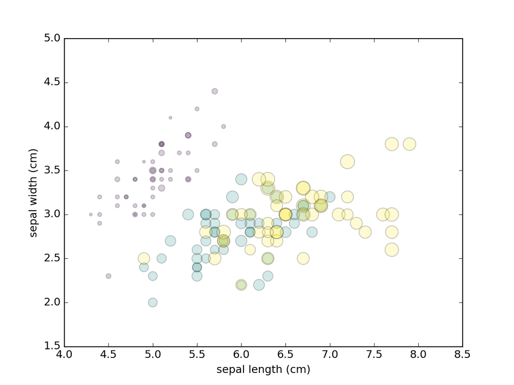

```python
caracteristicas = iris.data.T
#df1 = pd.DataFrame(caracteristicas, columns=caracteristicas.feature_names)

#print("Datos iniciales de IRIS vistos en un dataframe: ",df1.head(10))

#Ahora se grafica datos de la transpuesta.
plt.scatter(caracteristicas[0], caracteristicas[1],
            alpha=0.2,s=100*caracteristicas[3], c=iris.target, cmap='viridis')
plt.xlabel(iris.feature_names[0])
plt.ylabel(iris.feature_names[1])
plt.show()
```

## Graficación por bandas.

```python
# Plotenadola variaciÃ³n del error (por ejemplo en ValidaciÃ³n Cruzada)
plt.style.use('seaborn-whitegrid') # Define el estilo del grÃ¡fico

x = np.linspace(0, 10, 100)
dy = 0.8
y = np.sin(x) + dy * np.random.randn(100)
plt.errorbar(x, y, yerr=dy, fmt='.k')
# fmt es un cÃ³digo de formato que controla la apariencia de lÃneas y puntos
```

```
## <ErrorbarContainer object of 3 artists>
```

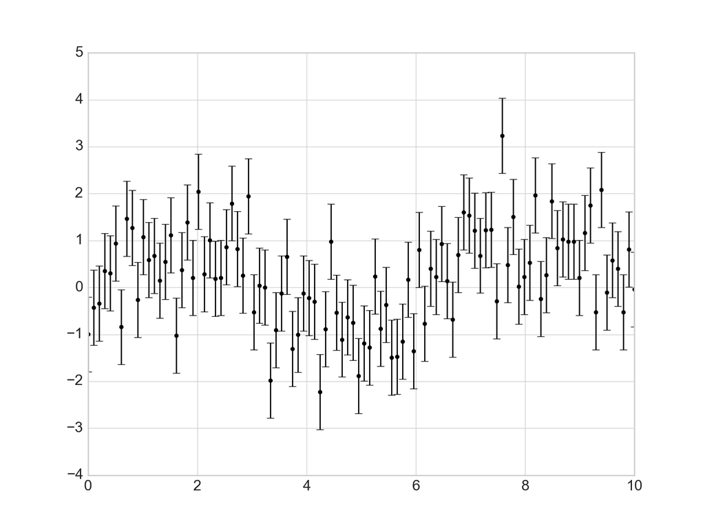

```python
plt.show()
```

## Histogramas

```python
# Ploteando Histogramas y Densidad
# Ejemplo 1
plt.style.use('seaborn-white')
datos = np.random.randn(1000)
plt.hist(datos)
```

```
## (array([ 10.,  36., 112., 175., 246., 219., 113.,  63.,  19.,   7.]), array([-2.828486  , -2.21747649, -1.60646697, -0.99545746, -0.38444794,
##         0.22656158,  0.83757109,  1.44858061,  2.05959012,  2.67059964,
##         3.28160915]), <BarContainer object of 10 artists>)
```

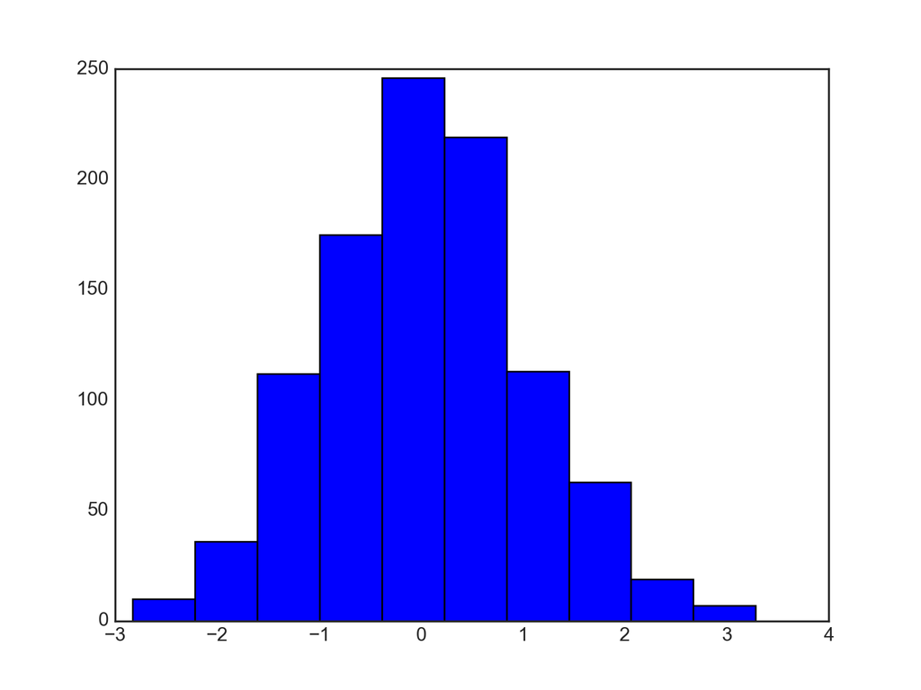

```python
plt.show()
```

## GGPlot

La librería ggplot es una alternativa en el manejo de gráficos con Python. Esta es conocida desde el lenguaje R y la versión para Python ofrece una forma alternativa de desarrollar interfaces gráficos con interfaces de datos.

En el siguiente ejemplo se muestra su uso.

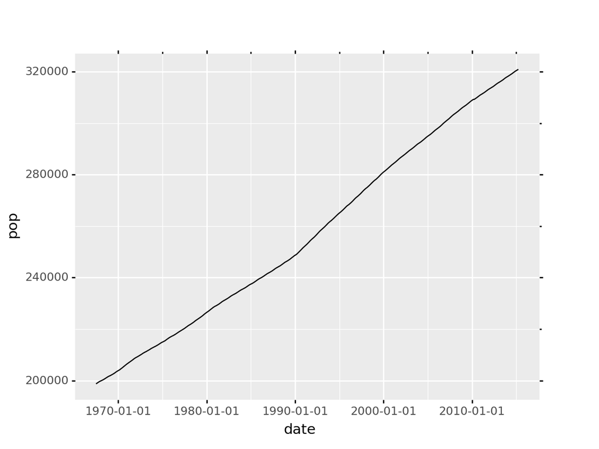

```python
from plotnine.data import economics
from plotnine.data import mpg
from plotnine.data import huron

from plotnine import ggplot, aes, geom_line,geom_point,geom_bar,stat_bin,geom_boxplot

x=(ggplot(economics) +
  aes(x="date", y="pop") +
  geom_line()
)
print(x)
```

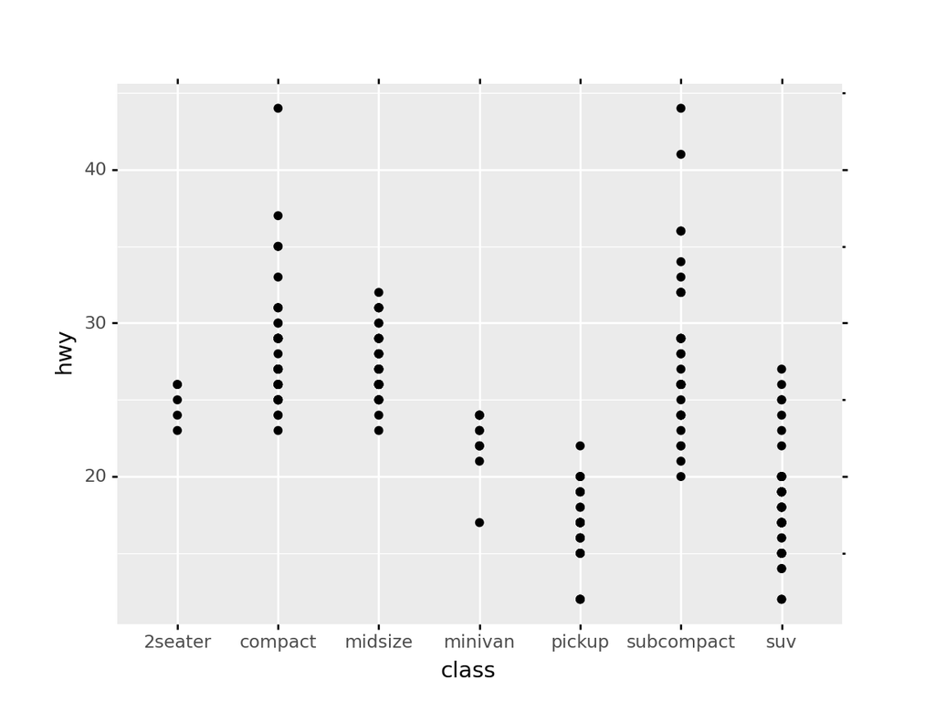

```python
ggplot(mpg) + aes(x="class", y="hwy") + geom_point()
```

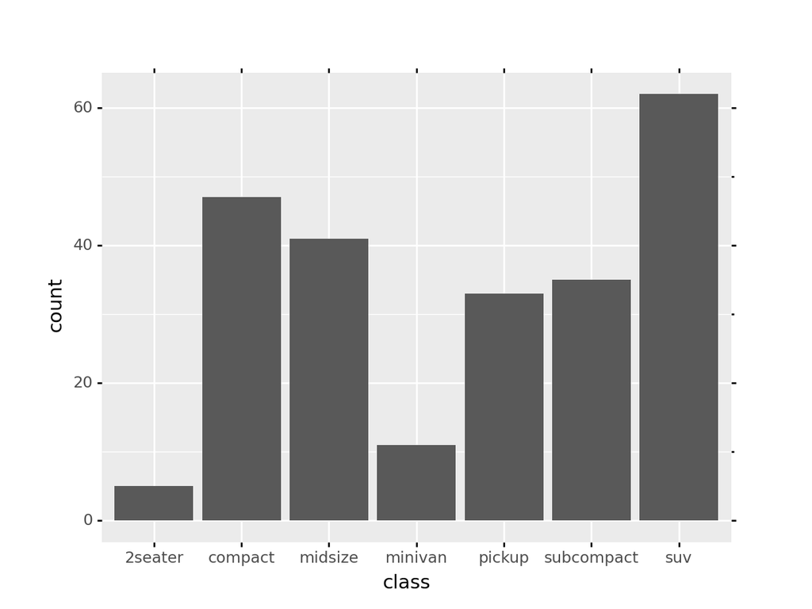

```python
ggplot(mpg) + aes(x="class") + geom_bar()
```

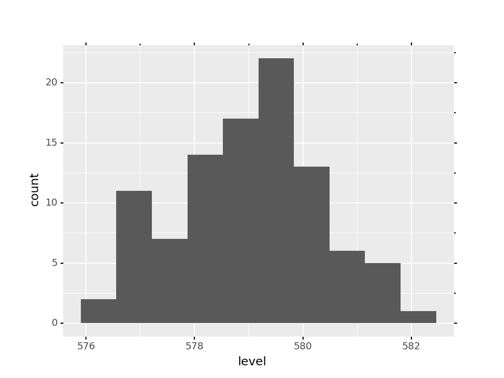

```python
ggplot(huron) + aes(x="level") + stat_bin(bins=10) + geom_bar()
```

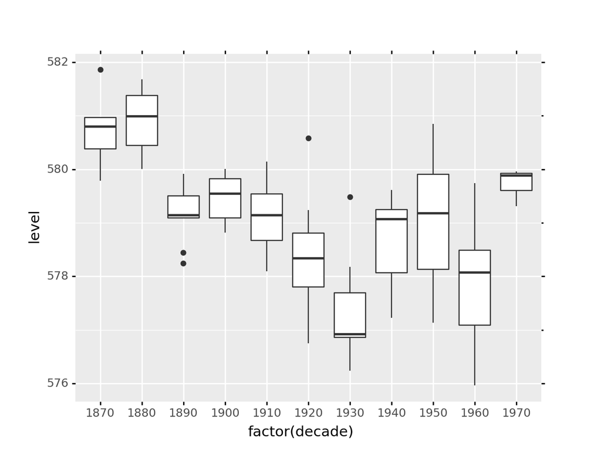

```python
ggplot(huron)  + aes(x="factor(decade)", y="level")  + geom_boxplot()
```